# Theta_logistic_model

## 埃及聖䴉防治策略效應分析

#### Theta logistic model with observation error for Population Viability Analysis

##### 特生中心 研究助理 曾子榮

###### 分析概念

- 使用彰化2015埃及聖䴉普查的資料建構模型
  > - 選擇模型  
  >   模型採用Theta logistic model with normal observation error，以貝氏統計法進行運算，並使用python 2.7的pymc3套件自行建構模型。理由如下：  
  >   1.以 **R** Package **PVAClone** 進行模式比較後，ricker(normal) model雖然優於theta-logistic(normal) model，但二者差距不大，且考慮到一般人對於theta-logistic model較熟悉，因此採用。  
  >   2.資料的收集過程中一定會受到觀測者誤差所影響，因此在模式中加入取樣誤差校正(normal observation error)。  
  >   3.貝氏分析法的強處之一在於，當樣本過少時，可使用合理設定的先驗資訊(Prior information)，使得計算的結果合理化。但是當樣本數極端的不足時，prior會非常強力的影響參數的走向，我手邊沒有恰當的資訊來設定參數，就只能參考*他人的基本設定* ( **R** Package **PVAClone** 中該模式的基本參數設定)進行微調。  
  >   4.為何使用pymc3自行建構模型？ **PVAClone** in **R**無法自行微調參數設定(或許可以，但我沒去研究)，因此要額外自己建構模型。pymc3是現今相當先進的MCMC計算模組，提供了極為先進的演算法(如NUTS: No U-Turn Sampler)，我因此採用。(PS：現今生態界使用貝氏統計主要是以bugs或jags軟體，使用的是較古老的演算法(Gibbs sampler)）
  > - 模型細節
  >   $N_t$ 為實際在時間$t$觀測到的族群量，在模式中全部先以$ln$轉換：
  >   Obervation model：
  >   (觀測到的族群量$N_t$是$X_t$加上常態分佈的觀測誤差$\tau$之後的結果)
  >   $\tau$ = 觀測誤差
  >   $$X_t \sim Normal(ln(N_t),\tau^2)$$ Process model (Theta-logistic growth)：
  >   $r$: 族群成長率
  >   $K$: 環境承載力
  >   $\theta$: 決定r和X的變化曲線曲度的參數
  >   (http://www.webpages.uidaho.edu/wlf448/2011/limitedgrowth.pdf)
  >   $\sigma$: 環境變異性
  >   $$X_t = X_{t−1} + r(1 − (e^{X_{t−1}}/K)^\theta) + \epsilon$$ $$\epsilon \sim Normal(0,\sigma^2)$$
  > - **參數設定** （不同設定會嚴重影響分析結果！！）
- 使用該模型得出的參數值進行模擬（2016/8 彰化調查到的隻數為起始數，設定不同情境模擬）

#### 建構模型

```python
#import the requied packages for calculation and visualization
%matplotlib inline
from matplotlib import pyplot as plt

import numpy as np
import pymc3 as pm
import theano.tensor as tt


plt.style.use('fivethirtyeight')
```

呈現關鍵參數群的**先驗資訊**：  
Show the **priors** for each key parameters：

> 由於建構模式的樣本數極少，**先驗資訊**會強烈的決定計算出來的參數群數值的走向，這很重要，所以我再次強調。 這是我個人認為這樣的分析最容易被質疑的地方。以下是這5個主要參數群的預設長相。

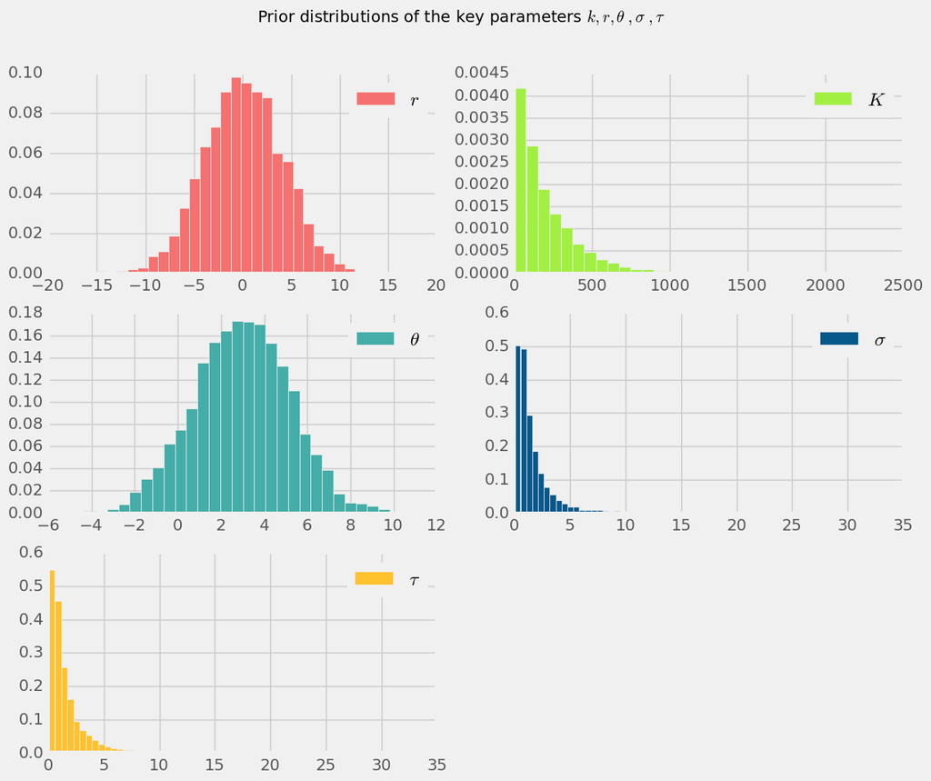

```python
plt.figure(figsize=(12,10))
plt.style.use('ggplot')
plt.style.use('fivethirtyeight')
plt.suptitle(r"Prior distributions of the key parameters $k,r,\theta\;,\sigma\;,\tau\;$")


ax = plt.subplot(321)
#ax.yaxis.set_visible(False)
plt.hist(np.random.normal(0,4,5000).tolist(),color='#F57170',bins=30,
         label="$r$",normed=True)
plt.legend()


ax = plt.subplot(322)
#ax.yaxis.set_visible(False)
plt.hist(np.random.exponential(1/0.005,5000).tolist(),color='#A2EF44',bins=30,
         label="$K$",normed=True)
plt.legend()

ax = plt.subplot(323)
#ax.yaxis.set_visible(False)
plt.hist(np.random.normal(3,2.25,5000).tolist(),color='#45ADA8',bins=30,
         label=r"$\theta$",normed=True)
plt.legend()

ax = plt.subplot(324)
#ax.yaxis.set_visible(False)
plt.hist(np.exp(np.random.normal(0,1,5000)).tolist(),color='#07588A',bins=60,
         label=r"$\sigma$",normed=True)
plt.legend()

ax = plt.subplot(325)
#ax.yaxis.set_visible(False)
plt.hist(np.exp(np.random.normal(0,1,5000)).tolist(),color='#FFC12D',bins=60,
         label=r"$\tau$",normed=True)
plt.legend()
```

以pymc3建構模型......不解釋......

```python
data = np.array([107,264,75,88,270,93])
log_data = np.log(data)

with pm.Model() as model:

    X=[]
    N=[]
    EX=[]
    mu=[]

    #setting Priors
    r = pm.Normal('r', 0, 4)
    K = pm.Exponential('K',0.005)
    #K = pm.Uniform('K',100,2000)
    theta = pm.Normal('theta',3,2.25)
    lnsigma = pm.Normal('lnsigma',0, 1)
    sigma = pm.Deterministic('sigma',tt.exp(lnsigma)) # process error (environment stochasticity)
    prcx = pm.Deterministic('prcx',1/sigma**2)
    lntau = pm.Normal('lntau',0,1)
    tau = pm.Deterministic('tau',tt.exp(lntau)) # this term is adding observation error
    prcy = pm.Deterministic('prcy',1/tau**2)


    X.append(log_data[0])
    N.append(log_data[0])
    EX.append(tt.exp(N[0]))


    for i in range(1,len(data)):
        mu.append(X[i-1] + r*(1-(EX[i-1]/K)**theta))
        X.append(pm.Normal('X'+str(i),mu[i-1],prcx)) #Process model
        N.append(pm.Normal('N'+str(i),X[i],prcy,observed=log_data[i])) #Observation model
        EX.append(tt.maximum(tt.exp(X[i]),1))
```

以NUTS計算，取樣20000筆，10000筆為burn-in，thin 5，共留存(20000-10000)/5 = 2000筆  
(因為使用NUTS，不用太多筆，這樣應該就夠了。)

```python
with model:
    #start = pm.find_MAP()
    trace = pm.sample(20000, step=pm.NUTS())
```

```python
varlist = ['r','K','theta','sigma','tau']
p_trace = trace[10000:][::5]
#p_trace = trace
```

呈現結果(Posterior)

```python
pm.summary(p_trace,varnames=varlist)
```

```
r:

  Mean             SD               MC Error         95% HPD interval
  -------------------------------------------------------------------

  0.499            1.498            0.066            [-3.390, 3.516]

  Posterior quantiles:
  2.5            25             50             75             97.5
  |--------------|==============|==============|--------------|

  -3.213         -0.006         0.450          1.060          3.745


K:

  Mean             SD               MC Error         95% HPD interval
  -------------------------------------------------------------------

  205.645          155.652          4.176            [0.680, 496.568]

  Posterior quantiles:
  2.5            25             50             75             97.5
  |--------------|==============|==============|--------------|

  33.173         123.387        169.257        229.075        653.129


theta:

  Mean             SD               MC Error         95% HPD interval
  -------------------------------------------------------------------

  1.738            1.914            0.066            [-1.223, 5.761]

  Posterior quantiles:
  2.5            25             50             75             97.5
  |--------------|==============|==============|--------------|

  -1.126         0.266          1.382          3.006          5.999
```

[output cut: 13 more lines]

```
  0.774          1.214          1.588          2.180          4.967


tau:

  Mean             SD               MC Error         95% HPD interval
  -------------------------------------------------------------------

  1.864            1.280            0.083            [0.678, 4.673]

  Posterior quantiles:
  2.5            25             50             75             97.5
  |--------------|==============|==============|--------------|

  0.836          1.169          1.422          2.043          5.789
```

```
array([[<matplotlib.axes._subplots.AxesSubplot object at 0x7f3fa3058510>],
       [<matplotlib.axes._subplots.AxesSubplot object at 0x7f3fa2f8a390>]], dtype=object)
```

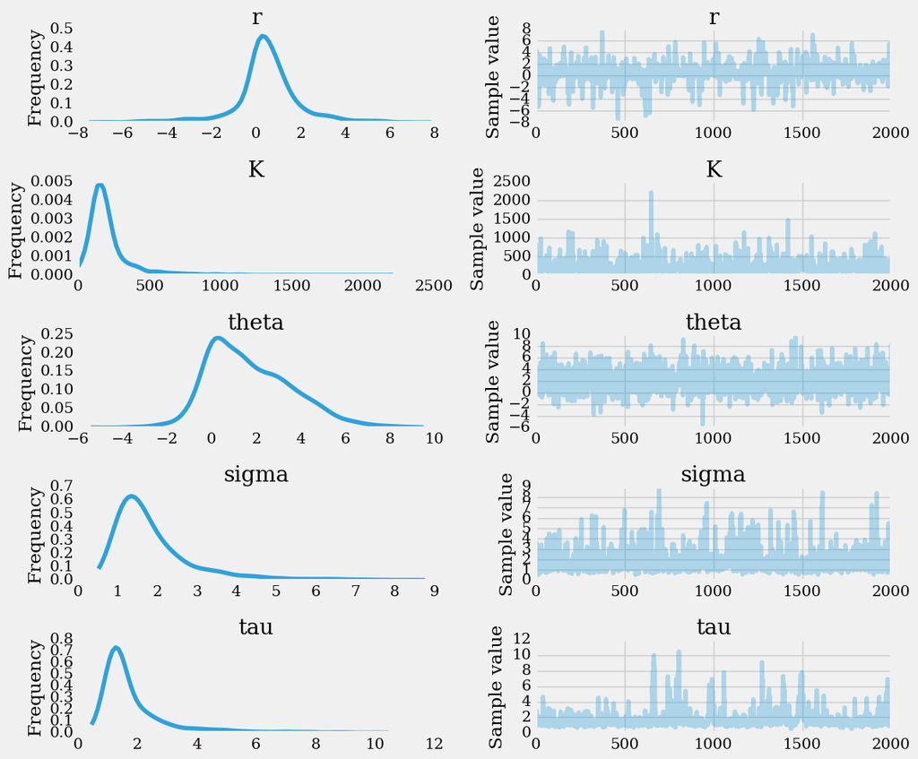

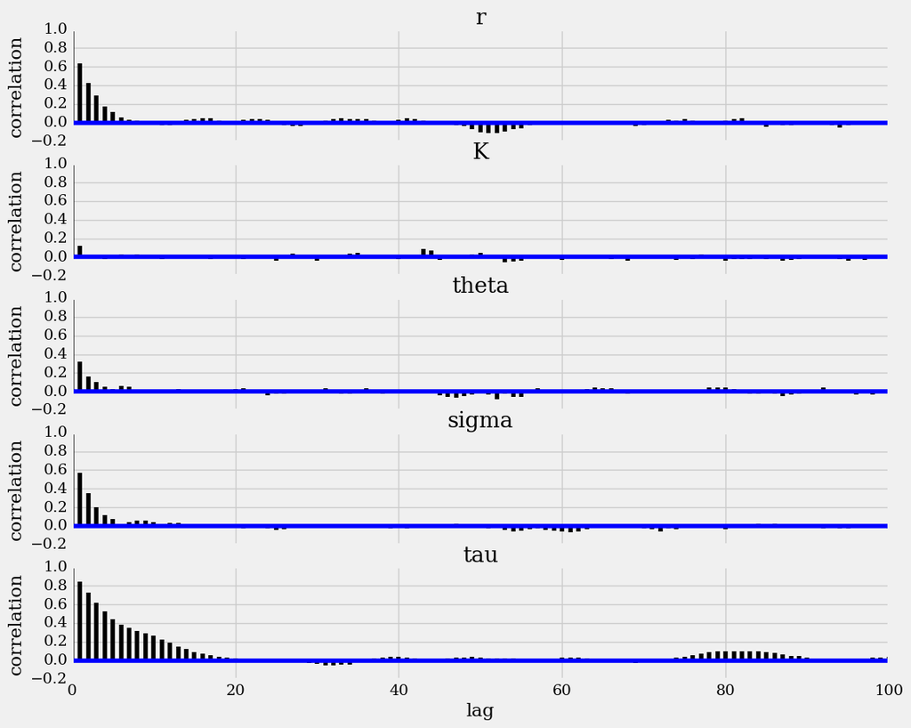

```python
#for i in varlist:
pm.plots.traceplot(trace=p_trace, varnames=varlist)
pm.plots.autocorrplot(trace=p_trace, varnames=varlist)
```

還ok，參數值可以用  
看一下各參數的長相:

```
array([<matplotlib.axes._subplots.AxesSubplot object at 0x7f3fb77cbc90>,
       <matplotlib.axes._subplots.AxesSubplot object at 0x7f3fb7deda90>], dtype=object)
```

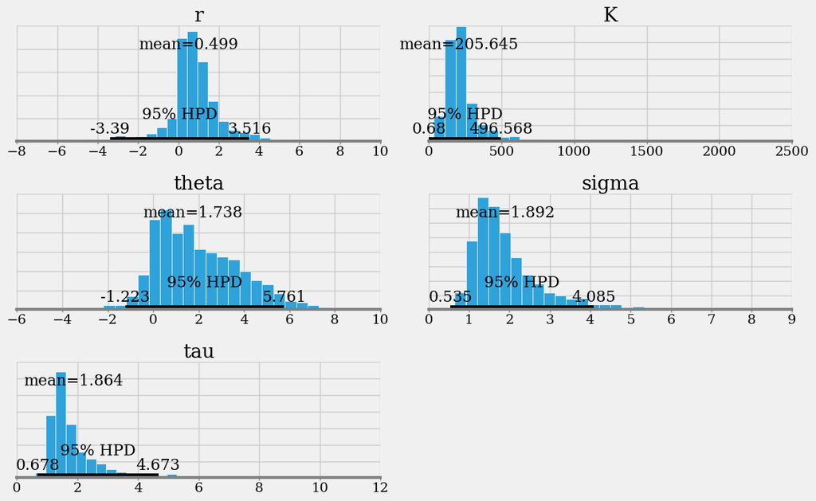

```python
pm.plots.plot_posterior(trace=p_trace, varnames=varlist)
```

可以將運算結果(posterior)的參數群與參數群的先驗資訊(prior)比對，可以發現兩者還蠻像的，如同我一開始說的，資料實在太少了，結果都被prior拉著走。

```python
# Let's run the simulations

# 卵的成功離巢率為1.2～1.5 / 2.5
# so it's a uniform(1.2/2.5,1.5/2.5)
N_future = 4
OUT =[]
while len(OUT)<5000:
    seed=int(np.random.uniform(0,len(p_trace['r'])))
    sim_X = []
    sim_X.append(np.random.normal(np.log(200),p_trace['prcy'][seed]))
    for i in range(1,N_future):
        seed=int(np.random.uniform(0,len(p_trace['r'])))
        sim_mu = (sim_X[i-1] + p_trace['r'][seed]*(1-(max(np.exp(sim_X[i-1]),1)/p_trace['K'][seed])**p_trace['theta'][seed]))
        if i ==1:
            success_recruit = np.random.uniform(1.2/2.5,1.5/2.5)
            sim_mu = np.log(np.exp(sim_mu) - 126*success_recruit)
        sim_X.append(np.random.normal(sim_mu,p_trace['prcx'][seed]))

    OUT.append(sim_X)
```

```python
## 模擬沒有干預行動的未來
N_future = 4
NO_OUT =[]
while len(NO_OUT)<5000:
    seed=int(np.random.uniform(0,len(p_trace['r'])))
    sim_X = []
    sim_X.append(np.random.normal(np.log(200),p_trace['prcy'][seed]))
    for i in range(1,N_future):
        seed=int(np.random.uniform(0,len(p_trace['r'])))
        sim_mu = (sim_X[i-1] + p_trace['r'][seed]*(1-(max(np.exp(sim_X[i-1]),1)/p_trace['K'][seed])**p_trace['theta'][seed]))
#         if i ==1:
#             success_recruit = np.random.uniform(1.2/2.5,1.5/2.5)
#             sim_mu = np.log(np.exp(sim_mu) - 126*success_recruit)
        sim_X.append(np.random.normal(sim_mu,p_trace['prcx'][seed]))

    NO_OUT.append(sim_X)
```

[figure not shown]

```python
O = np.stack(OUT,axis=0)
OO = np.stack([i for i in O if sum(i<8)+sum(i>2)==len(i)*2])

NO_O = np.stack(NO_OUT,axis=0)
NO_OO = np.stack([i for i in NO_O if sum(i<8)+sum(i>2)==len(i)*2])

figsize(12, 6)
plt.style.use('fivethirtyeight')
plt.rc('font', family='serif')

plt.plot(range(N_future),np.exp(np.percentile(OO,75,axis=0)),label='Q3')
plt.plot(range(N_future),np.exp(np.percentile(OO,50,axis=0)),label='Median')
plt.plot(range(N_future),np.exp(np.percentile(OO,25,axis=0)),label='Q1')
plt.fill_between(range(N_future),y1=np.exp(np.percentile(OO,2.5,axis=0)),y2=np.exp(np.percentile(OO,97.5,axis=0))\
                 ,label='95% CI',alpha=0.8,color='#FFCFDF')
plt.fill_between(range(N_future),y1=np.exp(np.percentile(NO_OO,2.5,axis=0)),y2=np.exp(np.percentile(NO_OO,97.5,axis=0))\
                 ,label='95% CI For No Intervention',alpha=0.8,color='#FFFDFB')

plt.annotate('', xy=(1, 200),xytext=(1, 300),arrowprops=dict(facecolor='black', shrink=0.05))
plt.text(0.75, 350,'Where I assume the Intervention\n effect take place',fontsize='x-small')
plt.xlim(-0.25,N_future-0.75)
plt.ylim(0,1000)
labels = ['2016_Aug.', '2016_Sep.', '2016_Oct.', '2016_Nov.']
plt.xticks(range(N_future), labels)
plt.ylabel('Simulated Population Size')
plt.title('Simulation results for intervention effect (egg removal)\n on Threskiornis aethiopicus',fontsize='medium',fontweight='bold')
plt.legend(loc="upper left",fontsize='x-small',shadow=True)
plt.show()
```

[figure not shown]

```python
O = np.stack(OUT,axis=0)
OO = np.stack([i for i in O if sum(i<8)+sum(i>2)==len(i)*2])

NO_O = np.stack(NO_OUT,axis=0)
NO_OO = np.stack([i for i in NO_O if sum(i<8)+sum(i>2)==len(i)*2])

figsize(12, 6)
plt.style.use('fivethirtyeight')
plt.rc('text', usetex=False)
plt.rc('font', family='serif')

plt.plot(range(N_future),np.exp(np.percentile(OO,75,axis=0)),label='Q3')
plt.plot(range(N_future),np.exp(np.percentile(OO,50,axis=0)),label='Median')
plt.plot(range(N_future),np.exp(np.percentile(OO,25,axis=0)),label='Q1')
# plt.fill_between(range(N_future),y1=np.exp(np.percentile(OO,2.5,axis=0)),y2=np.exp(np.percentile(OO,97.5,axis=0))\
#                  ,label='95% CI',alpha=0.8,color='#FFCFDF')
# plt.fill_between(range(N_future),y1=np.exp(np.percentile(NO_OO,2.5,axis=0)),y2=np.exp(np.percentile(NO_OO,97.5,axis=0))\
#                  ,label='95% CI For No Intervention',alpha=0.8,color='#FFFDFB')

plt.annotate('', xy=(1, -0.05),xytext=(1, 20),arrowprops=dict(facecolor='black',shrink=0.05,width=5))
plt.text(0.85, 22,'Where I assume the Intervention\n effect take place',fontsize='x-small')
plt.xlim(-0.25,N_future-0.75)
plt.ylim(0,300)
labels = ['2016_Aug.', '2016_Sep.', '2016_Oct.', '2016_Nov.']
plt.xticks(range(N_future), labels)
plt.ylabel('Simulated Population Size')
plt.title('Simulation results for intervention effect (egg removal)\n on Threskiornis aethiopicus',fontsize='medium',fontweight='bold')
plt.legend(loc="upper left",fontsize='x-small',shadow=True)
plt.show()
```

```python
np.percentile(OO,97.5,axis=0)
```

[output not shown]

```python
plt.style.available
```

```
[u'seaborn-darkgrid',
 u'seaborn-notebook',
 u'seaborn-muted',
 u'seaborn-ticks',
 u'grayscale',
 u'bmh',
 u'seaborn-talk',
 u'dark_background',
 u'ggplot',
 u'fivethirtyeight',
 u'seaborn-colorblind',
 u'seaborn-deep',
 u'seaborn-whitegrid',
 u'seaborn-bright',
 u'seaborn-poster',
 u'classic',
 u'seaborn-paper',
 u'seaborn-white',
 u'seaborn-pastel',
 u'seaborn-dark',
 u'seaborn-dark-palette']
```

```python
help(pm.plots.traceplot)
```

[output not shown]

```python
np.mean([i[2] for i in OUT if i[2]< 10 and i[2] >= 1])
```

```
4.6824379128049625
```

```python
np.mean([i[3] for i in OUT if i[3]< 10 and i[3] >= 1])
```

```
4.6896285571935321
```

```python
np.mean([i[4] for i in OUT if i[4]< 10 and i[4] >= 1])
```

[output not shown]

```python
help(pm.Normal)
```

[output not shown]